# Risk Factor Analysis

## Outcome Variable

**Outcome Variable:** whz

## Predictor Variables

**Intervention Variable:** nchldlt5

**Adjustment Set:**

unadjusted

## Stratifying Variables

The analysis was stratified on these variable(s):

- agecat
- studyid
- country

## Data Summary

| agecat | studyid | country | nchldlt5 | n_cell | n |
| --- | --- | --- | --- | --- | --- |
| Birth | ki1000108-IRC | INDIA | 1 | 72 | 343 |
| Birth | ki1000108-IRC | INDIA | 2+ | 271 | 343 |
| Birth | ki1017093b-PROVIDE | BANGLADESH | 1 | 385 | 532 |
| Birth | ki1017093b-PROVIDE | BANGLADESH | 2+ | 147 | 532 |
| Birth | ki1017093c-NIH-Crypto | BANGLADESH | 1 | 504 | 707 |
| Birth | ki1017093c-NIH-Crypto | BANGLADESH | 2+ | 203 | 707 |
| Birth | kiGH5241-JiVitA-3 | BANGLADESH | 1 | 10878 | 17991 |
| Birth | kiGH5241-JiVitA-3 | BANGLADESH | 2+ | 7113 | 17991 |
| 6 months | ki1000108-IRC | INDIA | 1 | 88 | 408 |
| 6 months | ki1000108-IRC | INDIA | 2+ | 320 | 408 |
| 6 months | ki1017093b-PROVIDE | BANGLADESH | 1 | 438 | 603 |
| 6 months | ki1017093b-PROVIDE | BANGLADESH | 2+ | 165 | 603 |
| 6 months | ki1017093c-NIH-Crypto | BANGLADESH | 1 | 507 | 715 |
| 6 months | ki1017093c-NIH-Crypto | BANGLADESH | 2+ | 208 | 715 |
| 6 months | ki1066203-TanzaniaChild2 | TANZANIA, UNITED REPUBLIC OF | 1 | 1390 | 2019 |
| 6 months | ki1066203-TanzaniaChild2 | TANZANIA, UNITED REPUBLIC OF | 2+ | 629 | 2019 |
| 6 months | ki1148112-LCNI-5 | MALAWI | 1 | 390 | 811 |
| 6 months | ki1148112-LCNI-5 | MALAWI | 2+ | 421 | 811 |
| 6 months | kiGH5241-JiVitA-3 | BANGLADESH | 1 | 10872 | 16773 |
| 6 months | kiGH5241-JiVitA-3 | BANGLADESH | 2+ | 5901 | 16773 |
| 24 months | ki1000108-IRC | INDIA | 1 | 89 | 409 |
| 24 months | ki1000108-IRC | INDIA | 2+ | 320 | 409 |
| 24 months | ki1017093b-PROVIDE | BANGLADESH | 1 | 424 | 579 |
| 24 months | ki1017093b-PROVIDE | BANGLADESH | 2+ | 155 | 579 |
| 24 months | ki1017093c-NIH-Crypto | BANGLADESH | 1 | 357 | 514 |
| 24 months | ki1017093c-NIH-Crypto | BANGLADESH | 2+ | 157 | 514 |
| 24 months | ki1066203-TanzaniaChild2 | TANZANIA, UNITED REPUBLIC OF | 1 | 5 | 6 |
| 24 months | ki1066203-TanzaniaChild2 | TANZANIA, UNITED REPUBLIC OF | 2+ | 1 | 6 |
| 24 months | ki1148112-LCNI-5 | MALAWI | 1 | 277 | 555 |
| 24 months | ki1148112-LCNI-5 | MALAWI | 2+ | 278 | 555 |
| 24 months | kiGH5241-JiVitA-3 | BANGLADESH | 1 | 5434 | 8593 |
| 24 months | kiGH5241-JiVitA-3 | BANGLADESH | 2+ | 3159 | 8593 |

The following strata were considered:

- agecat: 24 months, studyid: ki1000108-IRC, country: INDIA
- agecat: 24 months, studyid: ki1017093b-PROVIDE, country: BANGLADESH
- agecat: 24 months, studyid: ki1017093c-NIH-Crypto, country: BANGLADESH
- agecat: 24 months, studyid: ki1066203-TanzaniaChild2, country: TANZANIA, UNITED REPUBLIC OF
- agecat: 24 months, studyid: ki1148112-LCNI-5, country: MALAWI
- agecat: 24 months, studyid: kiGH5241-JiVitA-3, country: BANGLADESH
- agecat: 6 months, studyid: ki1000108-IRC, country: INDIA
- agecat: 6 months, studyid: ki1017093b-PROVIDE, country: BANGLADESH
- agecat: 6 months, studyid: ki1017093c-NIH-Crypto, country: BANGLADESH
- agecat: 6 months, studyid: ki1066203-TanzaniaChild2, country: TANZANIA, UNITED REPUBLIC OF
- agecat: 6 months, studyid: ki1148112-LCNI-5, country: MALAWI
- agecat: 6 months, studyid: kiGH5241-JiVitA-3, country: BANGLADESH
- agecat: Birth, studyid: ki1000108-IRC, country: INDIA
- agecat: Birth, studyid: ki1017093b-PROVIDE, country: BANGLADESH
- agecat: Birth, studyid: ki1017093c-NIH-Crypto, country: BANGLADESH
- agecat: Birth, studyid: kiGH5241-JiVitA-3, country: BANGLADESH

### Dropped Strata

Some strata were dropped due to rare outcomes:

- agecat: 24 months, studyid: ki1066203-TanzaniaChild2, country: TANZANIA, UNITED REPUBLIC OF

## Methods Detail

We’re interested in the causal parameters $E[Y_a]$ for all values of $a \in \mathcal{A}$. These parameters represent the mean outcome if, possibly contrary to fact, we intervened to set all units to have $A=a$. Under the randomization and positivity assumptions, these are identified by the statistical parameters $\psi_a=E_W[E_{Y|A,W}(Y|A=a,W)]$. In addition, we’re interested in the mean of $Y$, $E[Y]$ under no intervention (the observed mean). We will estimate these parameters by using SuperLearner to fit the relevant likelihood factors – $E_{Y|A,W}(Y|A=a,W)$ and $p(A=a|W)$, and then updating our likelihood fit using a joint TMLE.

For unadjusted analyses ($W=\{\}$), initial likelihoods were estimated using Lrnr_glm to estimate the simple $E(Y|A)$ and Lrnr_mean to estimate $p(A)$. For adjusted analyses, a small library containing Lrnr_glmnet, Lrnr_xgboost, and Lrnr_mean was used.

Having estimated these parameters, we will then use the delta method to estimate relative risks and attributable risks relative to a prespecified baseline level of $A$.

# Results Detail

## Results Plots

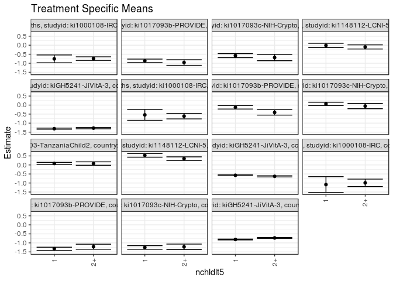

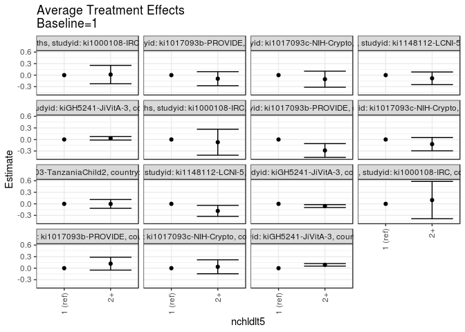

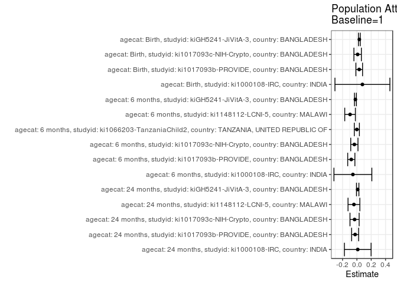

## Results Table

### Parameter: TSM

| agecat | studyid | country | intervention_level | baseline_level | estimate | ci_lower | ci_upper |
| --- | --- | --- | --- | --- | --- | --- | --- |
| Birth | ki1000108-IRC | INDIA | 1 | NA | -1.0877778 | -1.5272958 | -0.6482598 |
| Birth | ki1000108-IRC | INDIA | 2+ | NA | -0.9900738 | -1.1954663 | -0.7846813 |
| Birth | ki1017093b-PROVIDE | BANGLADESH | 1 | NA | -1.3309610 | -1.4223798 | -1.2395423 |
| Birth | ki1017093b-PROVIDE | BANGLADESH | 2+ | NA | -1.2133333 | -1.3536819 | -1.0729848 |
| Birth | ki1017093c-NIH-Crypto | BANGLADESH | 1 | NA | -1.2546726 | -1.3555497 | -1.1537956 |
| Birth | ki1017093c-NIH-Crypto | BANGLADESH | 2+ | NA | -1.2180296 | -1.3689050 | -1.0671541 |
| Birth | kiGH5241-JiVitA-3 | BANGLADESH | 1 | NA | -0.8119654 | -0.8361336 | -0.7877973 |
| Birth | kiGH5241-JiVitA-3 | BANGLADESH | 2+ | NA | -0.7252130 | -0.7507781 | -0.6996479 |
| 6 months | ki1000108-IRC | INDIA | 1 | NA | -0.5432576 | -0.8443752 | -0.2421399 |
| 6 months | ki1000108-IRC | INDIA | 2+ | NA | -0.6142396 | -0.7658485 | -0.4626307 |
| 6 months | ki1017093b-PROVIDE | BANGLADESH | 1 | NA | -0.1211454 | -0.2189300 | -0.0233607 |
| 6 months | ki1017093b-PROVIDE | BANGLADESH | 2+ | NA | -0.4060000 | -0.5563463 | -0.2556537 |
| 6 months | ki1017093c-NIH-Crypto | BANGLADESH | 1 | NA | 0.0648718 | -0.0288051 | 0.1585487 |
| 6 months | ki1017093c-NIH-Crypto | BANGLADESH | 2+ | NA | -0.0558173 | -0.2017213 | 0.0900867 |
| 6 months | ki1066203-TanzaniaChild2 | TANZANIA, UNITED REPUBLIC OF | 1 | NA | 0.0807812 | 0.0172916 | 0.1442708 |
| 6 months | ki1066203-TanzaniaChild2 | TANZANIA, UNITED REPUBLIC OF | 2+ | NA | 0.0788129 | -0.0165201 | 0.1741460 |
| 6 months | ki1148112-LCNI-5 | MALAWI | 1 | NA | 0.5331538 | 0.4311699 | 0.6351378 |
| 6 months | ki1148112-LCNI-5 | MALAWI | 2+ | NA | 0.3497862 | 0.2502659 | 0.4493066 |
| 6 months | kiGH5241-JiVitA-3 | BANGLADESH | 1 | NA | -0.5726577 | -0.5964699 | -0.5488456 |
| 6 months | kiGH5241-JiVitA-3 | BANGLADESH | 2+ | NA | -0.6311812 | -0.6619839 | -0.6003784 |
| 24 months | ki1000108-IRC | INDIA | 1 | NA | -0.7578277 | -0.9741065 | -0.5415489 |
| 24 months | ki1000108-IRC | INDIA | 2+ | NA | -0.7424740 | -0.8420220 | -0.6429259 |
| 24 months | ki1017093b-PROVIDE | BANGLADESH | 1 | NA | -0.8681014 | -0.9658147 | -0.7703881 |
| 24 months | ki1017093b-PROVIDE | BANGLADESH | 2+ | NA | -0.9606129 | -1.1146058 | -0.8066200 |
| 24 months | ki1017093c-NIH-Crypto | BANGLADESH | 1 | NA | -0.5780672 | -0.6902190 | -0.4659155 |
| 24 months | ki1017093c-NIH-Crypto | BANGLADESH | 2+ | NA | -0.6837580 | -0.8593352 | -0.5081807 |
| 24 months | ki1148112-LCNI-5 | MALAWI | 1 | NA | -0.0135018 | -0.1316207 | 0.1046171 |
| 24 months | ki1148112-LCNI-5 | MALAWI | 2+ | NA | -0.0958094 | -0.2101821 | 0.0185634 |
| 24 months | kiGH5241-JiVitA-3 | BANGLADESH | 1 | NA | -1.3085756 | -1.3377488 | -1.2794025 |
| 24 months | kiGH5241-JiVitA-3 | BANGLADESH | 2+ | NA | -1.2778791 | -1.3144698 | -1.2412884 |

### Parameter: E(Y)

| agecat | studyid | country | intervention_level | baseline_level | estimate | ci_lower | ci_upper |
| --- | --- | --- | --- | --- | --- | --- | --- |
| Birth | ki1000108-IRC | INDIA | NA | NA | -1.0105831 | -1.1973019 | -0.8238643 |
| Birth | ki1017093b-PROVIDE | BANGLADESH | NA | NA | -1.2984586 | -1.3752758 | -1.2216415 |
| Birth | ki1017093c-NIH-Crypto | BANGLADESH | NA | NA | -1.2441513 | -1.3281130 | -1.1601897 |
| Birth | kiGH5241-JiVitA-3 | BANGLADESH | NA | NA | -0.7776666 | -0.7966629 | -0.7586703 |
| 6 months | ki1000108-IRC | INDIA | NA | NA | -0.5989297 | -0.7344491 | -0.4634104 |
| 6 months | ki1017093b-PROVIDE | BANGLADESH | NA | NA | -0.1990907 | -0.2817968 | -0.1163845 |
| 6 months | ki1017093c-NIH-Crypto | BANGLADESH | NA | NA | 0.0297622 | -0.0491685 | 0.1086930 |
| 6 months | ki1066203-TanzaniaChild2 | TANZANIA, UNITED REPUBLIC OF | NA | NA | 0.0801680 | 0.0273223 | 0.1330136 |
| 6 months | ki1148112-LCNI-5 | MALAWI | NA | NA | 0.4379655 | 0.3664533 | 0.5094777 |
| 6 months | kiGH5241-JiVitA-3 | BANGLADESH | NA | NA | -0.5932472 | -0.6127728 | -0.5737215 |
| 24 months | ki1000108-IRC | INDIA | NA | NA | -0.7458150 | -0.8368180 | -0.6548120 |
| 24 months | ki1017093b-PROVIDE | BANGLADESH | NA | NA | -0.8928670 | -0.9755153 | -0.8102187 |
| 24 months | ki1017093c-NIH-Crypto | BANGLADESH | NA | NA | -0.6103502 | -0.7050157 | -0.5156847 |
| 24 months | ki1148112-LCNI-5 | MALAWI | NA | NA | -0.0547297 | -0.1370054 | 0.0275459 |
| 24 months | kiGH5241-JiVitA-3 | BANGLADESH | NA | NA | -1.2972908 | -1.3206179 | -1.2739638 |

### Parameter: ATE

| agecat | studyid | country | intervention_level | baseline_level | estimate | ci_lower | ci_upper |
| --- | --- | --- | --- | --- | --- | --- | --- |
| Birth | ki1000108-IRC | INDIA | 1 | 1 | 0.0000000 | 0.0000000 | 0.0000000 |
| Birth | ki1000108-IRC | INDIA | 2+ | 1 | 0.0977040 | -0.3874374 | 0.5828454 |
| Birth | ki1017093b-PROVIDE | BANGLADESH | 1 | 1 | 0.0000000 | 0.0000000 | 0.0000000 |
| Birth | ki1017093b-PROVIDE | BANGLADESH | 2+ | 1 | 0.1176277 | -0.0498689 | 0.2851243 |
| Birth | ki1017093c-NIH-Crypto | BANGLADESH | 1 | 1 | 0.0000000 | 0.0000000 | 0.0000000 |
| Birth | ki1017093c-NIH-Crypto | BANGLADESH | 2+ | 1 | 0.0366431 | -0.1448496 | 0.2181357 |
| Birth | kiGH5241-JiVitA-3 | BANGLADESH | 1 | 1 | 0.0000000 | 0.0000000 | 0.0000000 |
| Birth | kiGH5241-JiVitA-3 | BANGLADESH | 2+ | 1 | 0.0867524 | 0.0543744 | 0.1191305 |
| 6 months | ki1000108-IRC | INDIA | 1 | 1 | 0.0000000 | 0.0000000 | 0.0000000 |
| 6 months | ki1000108-IRC | INDIA | 2+ | 1 | -0.0709820 | -0.4081127 | 0.2661487 |
| 6 months | ki1017093b-PROVIDE | BANGLADESH | 1 | 1 | 0.0000000 | 0.0000000 | 0.0000000 |
| 6 months | ki1017093b-PROVIDE | BANGLADESH | 2+ | 1 | -0.2848546 | -0.4642031 | -0.1055062 |
| 6 months | ki1017093c-NIH-Crypto | BANGLADESH | 1 | 1 | 0.0000000 | 0.0000000 | 0.0000000 |
| 6 months | ki1017093c-NIH-Crypto | BANGLADESH | 2+ | 1 | -0.1206891 | -0.2940769 | 0.0526987 |
| 6 months | ki1066203-TanzaniaChild2 | TANZANIA, UNITED REPUBLIC OF | 1 | 1 | 0.0000000 | 0.0000000 | 0.0000000 |
| 6 months | ki1066203-TanzaniaChild2 | TANZANIA, UNITED REPUBLIC OF | 2+ | 1 | -0.0019682 | -0.1165079 | 0.1125714 |
| 6 months | ki1148112-LCNI-5 | MALAWI | 1 | 1 | 0.0000000 | 0.0000000 | 0.0000000 |
| 6 months | ki1148112-LCNI-5 | MALAWI | 2+ | 1 | -0.1833676 | -0.3258633 | -0.0408719 |
| 6 months | kiGH5241-JiVitA-3 | BANGLADESH | 1 | 1 | 0.0000000 | 0.0000000 | 0.0000000 |
| 6 months | kiGH5241-JiVitA-3 | BANGLADESH | 2+ | 1 | -0.0585234 | -0.0960951 | -0.0209517 |
| 24 months | ki1000108-IRC | INDIA | 1 | 1 | 0.0000000 | 0.0000000 | 0.0000000 |
| 24 months | ki1000108-IRC | INDIA | 2+ | 1 | 0.0153538 | -0.2227352 | 0.2534427 |
| 24 months | ki1017093b-PROVIDE | BANGLADESH | 1 | 1 | 0.0000000 | 0.0000000 | 0.0000000 |
| 24 months | ki1017093b-PROVIDE | BANGLADESH | 2+ | 1 | -0.0925115 | -0.2748894 | 0.0898664 |
| 24 months | ki1017093c-NIH-Crypto | BANGLADESH | 1 | 1 | 0.0000000 | 0.0000000 | 0.0000000 |
| 24 months | ki1017093c-NIH-Crypto | BANGLADESH | 2+ | 1 | -0.1056907 | -0.3140303 | 0.1026489 |
| 24 months | ki1148112-LCNI-5 | MALAWI | 1 | 1 | 0.0000000 | 0.0000000 | 0.0000000 |
| 24 months | ki1148112-LCNI-5 | MALAWI | 2+ | 1 | -0.0823075 | -0.2467253 | 0.0821102 |
| 24 months | kiGH5241-JiVitA-3 | BANGLADESH | 1 | 1 | 0.0000000 | 0.0000000 | 0.0000000 |
| 24 months | kiGH5241-JiVitA-3 | BANGLADESH | 2+ | 1 | 0.0306966 | -0.0150417 | 0.0764348 |

### Parameter: PAR

| agecat | studyid | country | intervention_level | baseline_level | estimate | ci_lower | ci_upper |
| --- | --- | --- | --- | --- | --- | --- | --- |
| Birth | ki1000108-IRC | INDIA | 1 | NA | 0.0771947 | -0.3061326 | 0.4605220 |
| Birth | ki1017093b-PROVIDE | BANGLADESH | 1 | NA | 0.0325024 | -0.0139953 | 0.0790001 |
| Birth | ki1017093c-NIH-Crypto | BANGLADESH | 1 | NA | 0.0105213 | -0.0416048 | 0.0626474 |
| Birth | kiGH5241-JiVitA-3 | BANGLADESH | 1 | NA | 0.0342988 | 0.0215223 | 0.0470754 |
| 6 months | ki1000108-IRC | INDIA | 1 | NA | -0.0556722 | -0.3201036 | 0.2087593 |
| 6 months | ki1017093b-PROVIDE | BANGLADESH | 1 | NA | -0.0779453 | -0.1280583 | -0.0278323 |
| 6 months | ki1017093c-NIH-Crypto | BANGLADESH | 1 | NA | -0.0351096 | -0.0857096 | 0.0154905 |
| 6 months | ki1066203-TanzaniaChild2 | TANZANIA, UNITED REPUBLIC OF | 1 | NA | -0.0006132 | -0.0362969 | 0.0350705 |
| 6 months | ki1148112-LCNI-5 | MALAWI | 1 | NA | -0.0951884 | -0.1694282 | -0.0209485 |
| 6 months | kiGH5241-JiVitA-3 | BANGLADESH | 1 | NA | -0.0205894 | -0.0338340 | -0.0073448 |
| 24 months | ki1000108-IRC | INDIA | 1 | NA | 0.0120127 | -0.1742681 | 0.1982936 |
| 24 months | ki1017093b-PROVIDE | BANGLADESH | 1 | NA | -0.0247656 | -0.0737027 | 0.0241716 |
| 24 months | ki1017093c-NIH-Crypto | BANGLADESH | 1 | NA | -0.0322830 | -0.0960590 | 0.0314931 |
| 24 months | ki1148112-LCNI-5 | MALAWI | 1 | NA | -0.0412279 | -0.1236562 | 0.0412003 |
| 24 months | kiGH5241-JiVitA-3 | BANGLADESH | 1 | NA | 0.0112848 | -0.0055607 | 0.0281303 |